# ARIMA models using fpp3 package by Hyndmann

# 4 Seasonal and Trend decomposition using Loess: Time Series Decomposition

https://otexts.com/fpp3/stl.html#stl

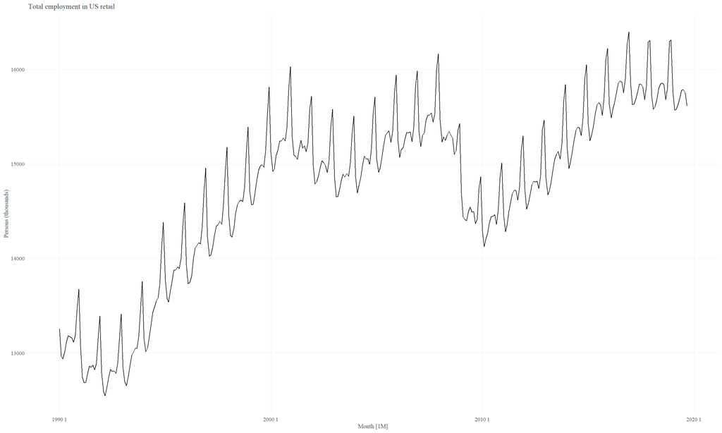

```r
us_retail_employment <- us_employment |>
    filter(year(Month) >= 1990, Title == "Retail Trade") |>
    select(-Series_ID)

autoplot(us_retail_employment, Employed) +
    labs(y = "Persons (thousands)", title = "Total employment in US retail")
```

- The two main parameters to be chosen when using STL are the trend-cycle window trend(window = …) and the seasonal window season(window = …). These control how rapidly the trend-cycle and seasonal components can change. Smaller values allow for more rapid changes. Both trend and seasonal windows should be odd numbers.
- By default, the STL() function provides a convenient automated STL decomposition using a seasonal window of season (window = 13), and the trend window chosen automatically from the seasonal period.
- The default setting for monthly data is trend (window = 21). This usually gives a good balance between overfitting the seasonality and allowing it to slowly change over time. But, as with any automated procedure, the default settings will need adjusting for some time series.

```r
dcmp <- us_retail_employment |>
    model(
        STL(Employed ~ trend(window = 7) + season(window = "periodic"),
            robust = TRUE)
    )

components(dcmp)
```

```
## # A dable: 357 x 7 [1M]
## # Key:     .model [1]
## # :        Employed = trend + season_year + remainder
##    .model                           Month Emplo…¹  trend seaso…² remai…³ seaso…⁴
##    <chr>                            <mth>   <dbl>  <dbl>   <dbl>   <dbl>   <dbl>
##  1 "STL(Employed ~ trend(window …  1990 1  13256. 13250.  -83.1    88.7   13339.
##  2 "STL(Employed ~ trend(window …  1990 2  12966. 13234. -279.     11.1   13245.
##  3 "STL(Employed ~ trend(window …  1990 3  12938. 13220. -266.    -15.4   13204.
##  4 "STL(Employed ~ trend(window …  1990 4  13012. 13206. -190.     -3.00  13203.
##  5 "STL(Employed ~ trend(window …  1990 5  13108. 13197.  -91.0     2.48  13199.
##  6 "STL(Employed ~ trend(window …  1990 6  13183. 13189.   -9.67    3.44  13192.
##  7 "STL(Employed ~ trend(window …  1990 7  13170. 13181.   -8.50   -2.14  13179.
##  8 "STL(Employed ~ trend(window …  1990 8  13160. 13172.   -6.51   -6.04  13166.
##  9 "STL(Employed ~ trend(window …  1990 9  13113. 13158.  -86.0    41.3   13199.
## 10 "STL(Employed ~ trend(window … 1990 10  13185. 13139.   43.7     2.88  13141.
## # … with 347 more rows, and abbreviated variable names ¹Employed, ²season_year,
## #   ³remainder, ⁴season_adjust
```

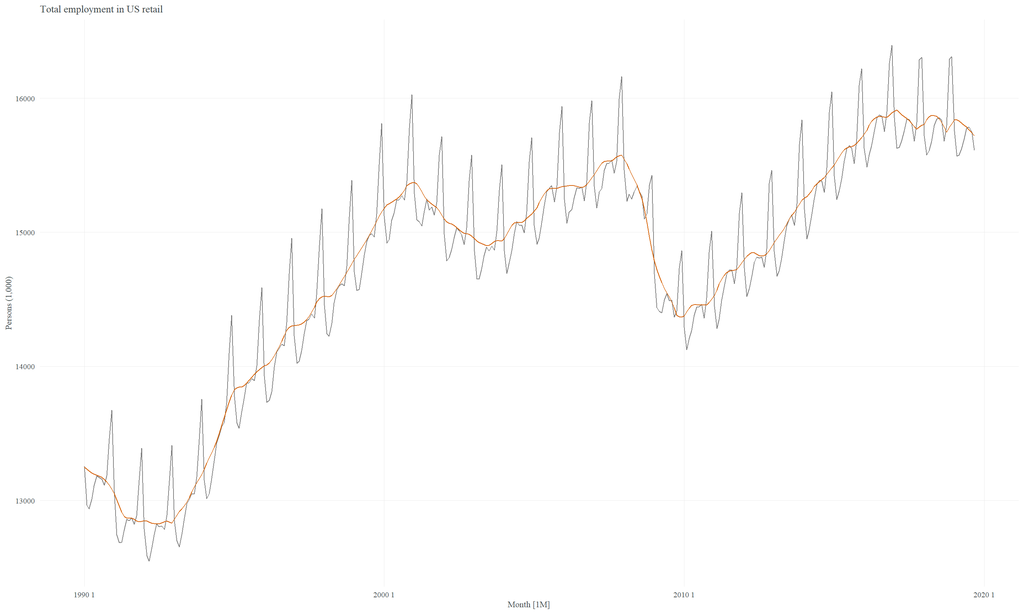

```r
components(dcmp) |>
    as_tsibble() |>
    autoplot(Employed, colour = "gray50") +
    geom_line(aes(y = trend), colour = "#D55E00") +
    labs(y = "Persons (1,000)", title = "Total employment in US retail")
```

- If the seasonal component is removed from the original data, the resulting values are the seasonally adjusted data.

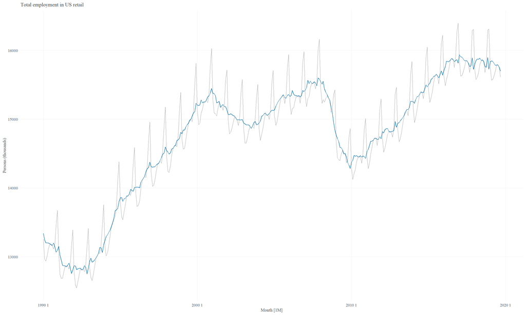

```r
components(dcmp) |>
    as_tsibble() |>
    autoplot(Employed, colour = "gray") +
    geom_line(aes(y = season_adjust), colour = "#0072B2") +
    labs(y = "Persons (thousands)",
         title = "Total employment in US retail")
```

- The grey bars to the left of each panel show the relative scales of the components. Each grey bar represents the same length but because the plots are on different scales, the bars vary in size.

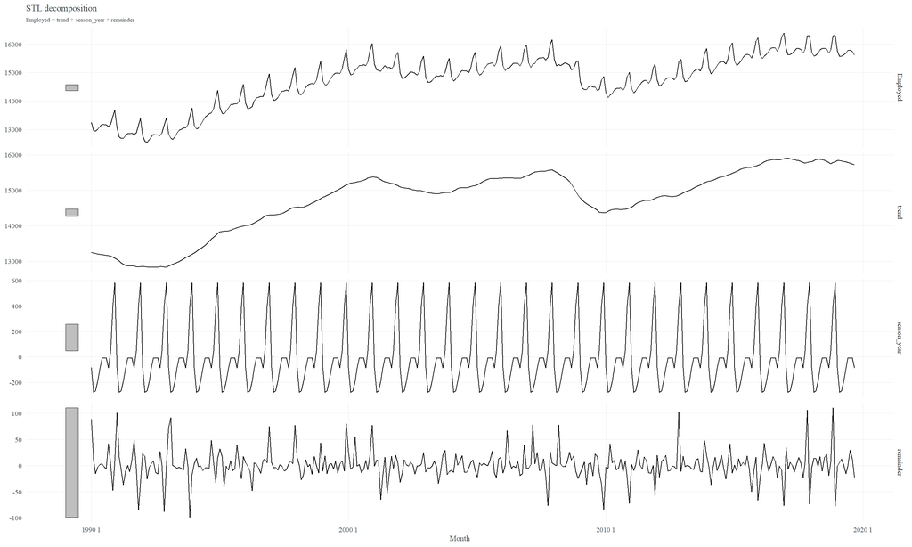

```r
components(dcmp) |> autoplot()
```

# 5 ACFs

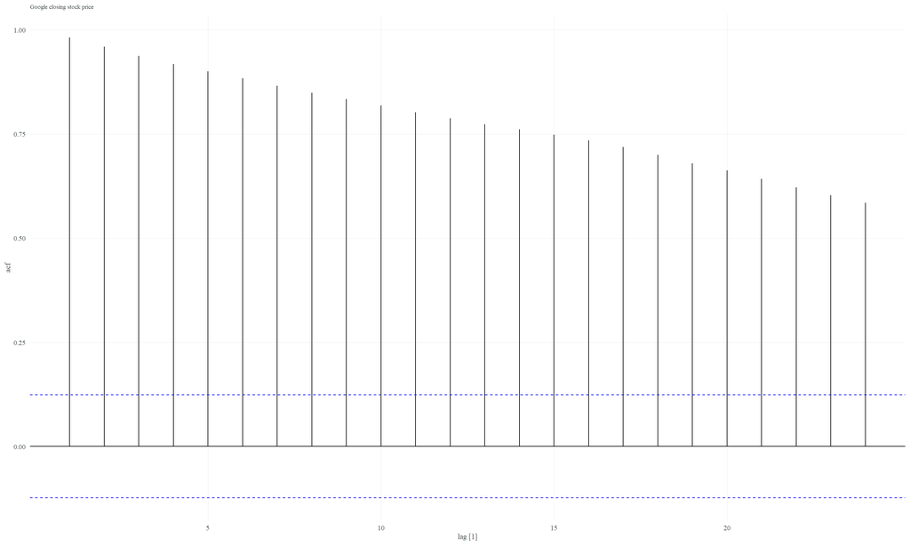

```r
google_2015 |> ACF(Close) |>
    autoplot() + labs(subtitle = "Google closing stock price")
```

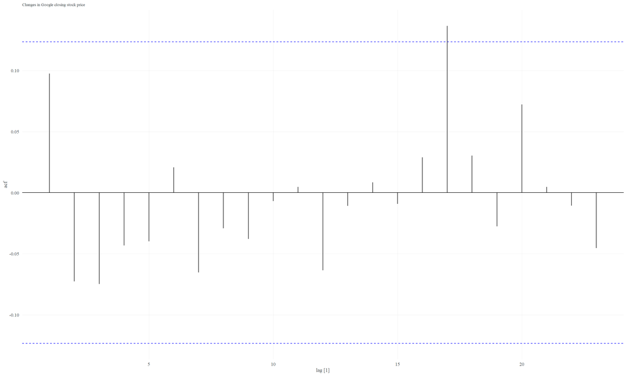

```r
google_2015 |> ACF(difference(Close)) |>
    autoplot() + labs(subtitle = "Changes in Google closing stock price")
```

# 6 Ljung-Box Statistics

https://otexts.com/fpp3/diagnostics.html#portmanteau-tests-for-autocorrelation

```r
google_2015 |>
    mutate(diff_close = difference(Close)) |>
    features(diff_close, ljung_box, lag = 10)
```

```
## # A tibble: 1 × 3
##   Symbol lb_stat lb_pvalue
##   <chr>    <dbl>     <dbl>
## 1 GOOG      7.91     0.637
```

# 7 Unit Root Tests (KPSS)

The null hypothesis: The data are stationary.  
We look for evidence that the null hypothesis is false.

```r
google_2015 |>
    features(Close, unitroot_kpss)
```

```
## # A tibble: 1 × 3
##   Symbol kpss_stat kpss_pvalue
##   <chr>      <dbl>       <dbl>
## 1 GOOG        3.56        0.01
```

```r
google_2015 |>
    mutate(diff_close = difference(Close)) |>
    features(diff_close, unitroot_kpss)
```

```
## # A tibble: 1 × 3
##   Symbol kpss_stat kpss_pvalue
##   <chr>      <dbl>       <dbl>
## 1 GOOG      0.0989         0.1
```

# 8 Determine the min_num of differences (lag) necessary to obtain a stationary time series

```r
google_2015 %>% features(Close, unitroot_ndiffs)
```

```
## # A tibble: 1 × 2
##   Symbol ndiffs
##   <chr>   <int>
## 1 GOOG        1
```

# 9 Time Series CV

https://otexts.com/fpp3/tscv.html#tscv

```r
google_2015_tr <- google_2015 |>
    stretch_tsibble(.init = 3, .step = 1) |>
    relocate(Date, Symbol, .id)
google_2015_tr
```

```
## # A tsibble: 31,875 x 9 [!]
## # Key:       Symbol, .id [250]
##    Date       Symbol   .id  Open  High   Low Close Adj_Close  Volume
##    <date>     <chr>  <int> <dbl> <dbl> <dbl> <dbl>     <dbl>   <dbl>
##  1 2015-01-02 GOOG       1  526.  528.  521.  522.      522. 1447600
##  2 2015-01-05 GOOG       1  520.  521.  510.  511.      511. 2059800
##  3 2015-01-06 GOOG       1  512.  513.  498.  499.      499. 2899900
##  4 2015-01-02 GOOG       2  526.  528.  521.  522.      522. 1447600
##  5 2015-01-05 GOOG       2  520.  521.  510.  511.      511. 2059800
##  6 2015-01-06 GOOG       2  512.  513.  498.  499.      499. 2899900
##  7 2015-01-07 GOOG       2  504.  504.  497.  498.      498. 2065100
##  8 2015-01-02 GOOG       3  526.  528.  521.  522.      522. 1447600
##  9 2015-01-05 GOOG       3  520.  521.  510.  511.      511. 2059800
## 10 2015-01-06 GOOG       3  512.  513.  498.  499.      499. 2899900
## # … with 31,865 more rows
```

# 10 Non-seasonal ARIMA Modelling

## 10.1 ACF and PACF

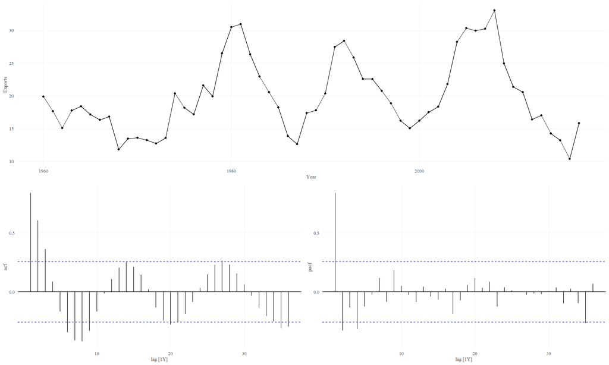

```r
global_economy |>
    filter(Code == "EGY") |>
    gg_tsdisplay(Exports, plot_type = 'partial', lag = 36)
```

## 10.2 Single (non-differenced) Modelling

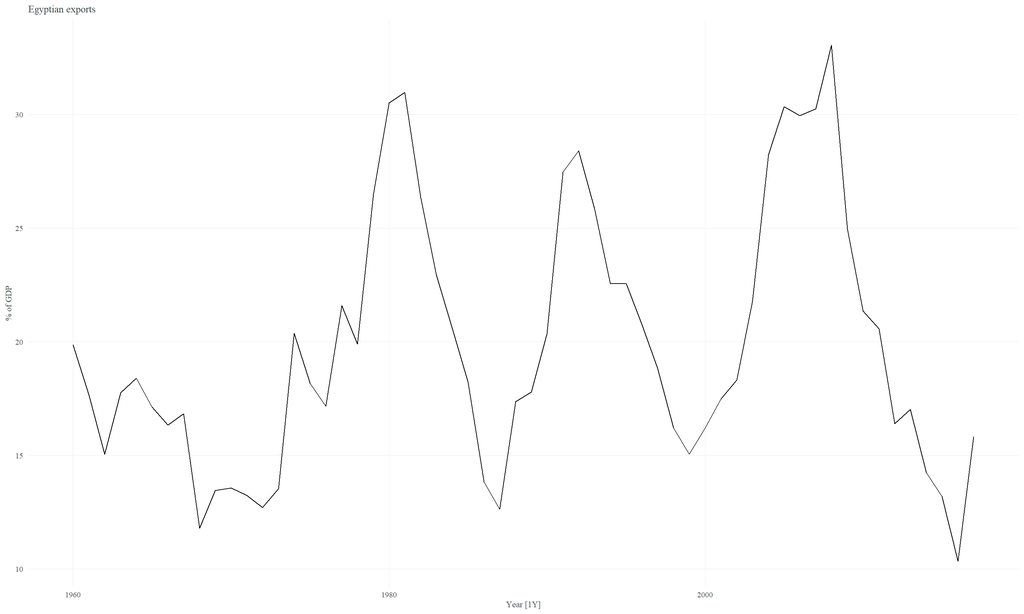

```r
global_economy |>
    filter(Code == "EGY") |>
    autoplot(Exports) +
    labs(y = "% of GDP", title = "Egyptian exports")
```

```r
fit <- global_economy |>
    filter(Code == "EGY") |>
    model(ARIMA(Exports, stepwise = TRUE))

report(fit)  # convert coefficients w/ Backshift operators to canonical coefficients
```

```
## Series: Exports
## Model: ARIMA(2,0,1) w/ mean
##
## Coefficients:
##          ar1      ar2      ma1  constant
##       1.6764  -0.8034  -0.6896    2.5623
## s.e.  0.1111   0.0928   0.1492    0.1161
##
## sigma^2 estimated as 8.046:  log likelihood=-141.57
## AIC=293.13   AICc=294.29   BIC=303.43
```

### 10.2.1 Residuals

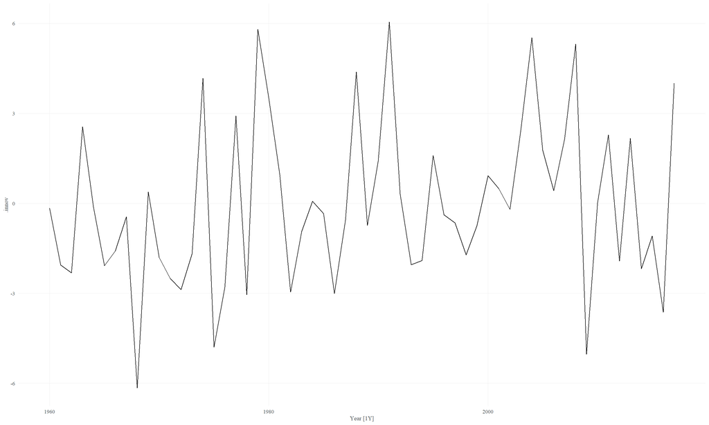

```r
fit %>% augment() %>% autoplot(.innov)
```

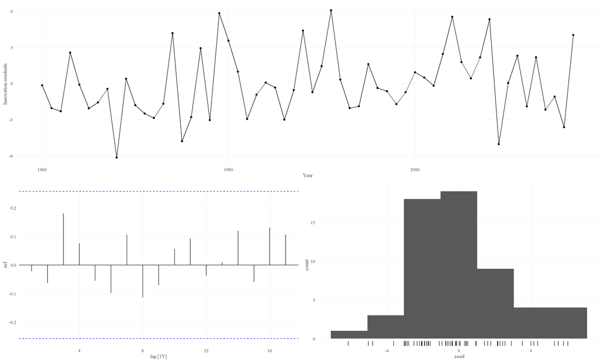

```r
fit %>% gg_tsresiduals()
```

### 10.2.2 Forecast

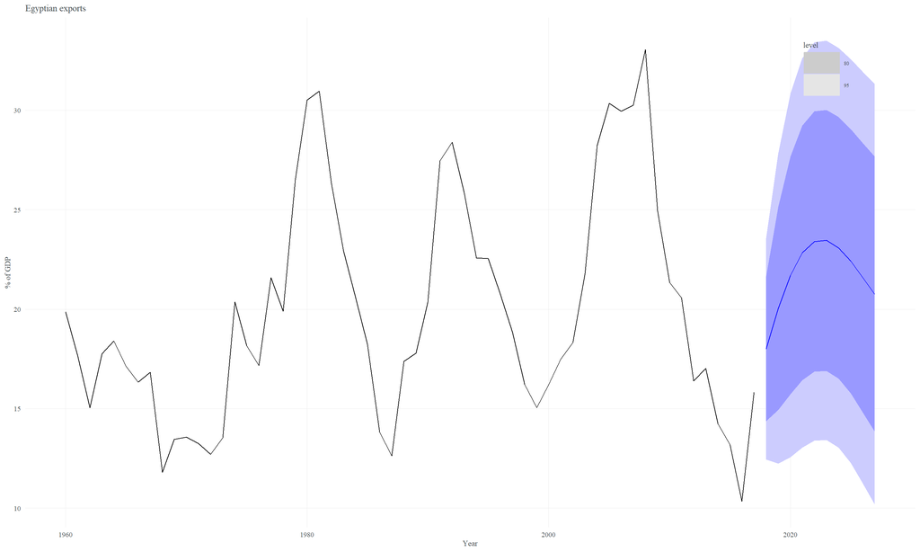

```r
fit |> forecast(h = 10) |>
    autoplot(global_economy) +
    labs(y = "% of GDP", title = "Egyptian exports")
```

```r
fit |> forecast(h = 10) |> hilo()
```

```
## # A tsibble: 10 x 7 [1Y]
## # Key:       Country, .model [1]
##    Country          .model           Year   Exports .mean                  `80%`
##    <fct>            <chr>           <dbl>    <dist> <dbl>                 <hilo>
##  1 Egypt, Arab Rep. ARIMA(Exports,…  2018  N(18, 8)  18.0 [14.37230, 21.64260]80
##  2 Egypt, Arab Rep. ARIMA(Exports,…  2019 N(20, 16)  20.0 [14.93480, 25.14894]80
##  3 Egypt, Arab Rep. ARIMA(Exports,…  2020 N(22, 22)  21.7 [15.72302, 27.66449]80
##  4 Egypt, Arab Rep. ARIMA(Exports,…  2021 N(23, 25)  22.8 [16.42890, 29.22822]80
##  5 Egypt, Arab Rep. ARIMA(Exports,…  2022 N(23, 26)  23.4 [16.85781, 29.94987]80
##  6 Egypt, Arab Rep. ARIMA(Exports,…  2023 N(23, 26)  23.5 [16.89458, 30.01850]80
##  7 Egypt, Arab Rep. ARIMA(Exports,…  2024 N(23, 26)  23.1 [16.51195, 29.65345]80
##  8 Egypt, Arab Rep. ARIMA(Exports,…  2025 N(22, 27)  22.4 [15.77646, 29.05083]80
##  9 Egypt, Arab Rep. ARIMA(Exports,…  2026 N(22, 28)  21.6 [14.82956, 28.35517]80
## 10 Egypt, Arab Rep. ARIMA(Exports,…  2027 N(21, 29)  20.8 [13.84230, 27.66385]80
## # … with 1 more variable: `95%` <hilo>
```

## 10.3 Multiple Modelling: model selection with AICc

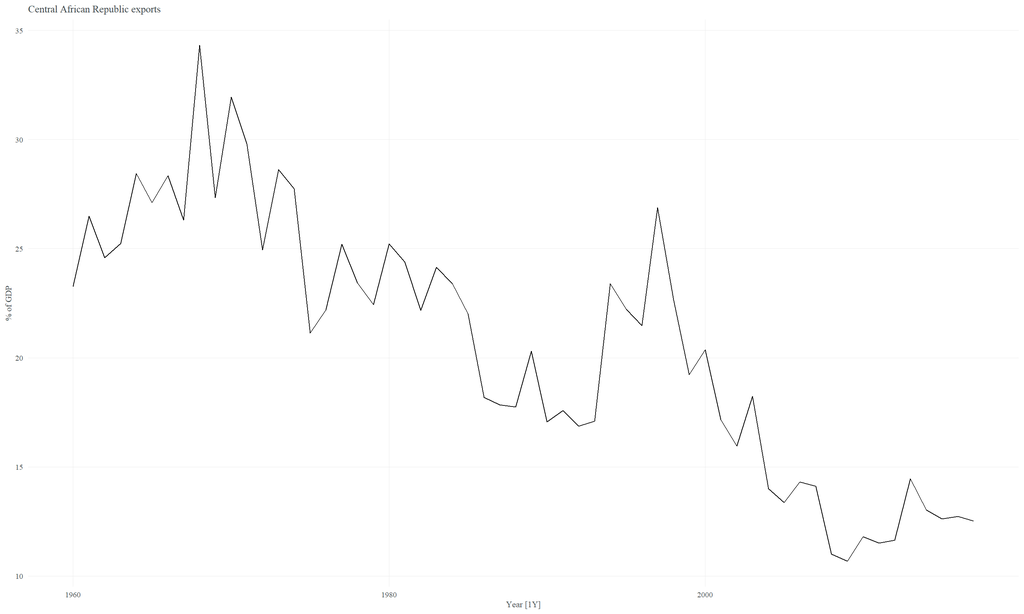

```r
global_economy |>
    filter(Code == "CAF") |>
    autoplot(Exports) +
    labs(title = "Central African Republic exports", y = "% of GDP")
```

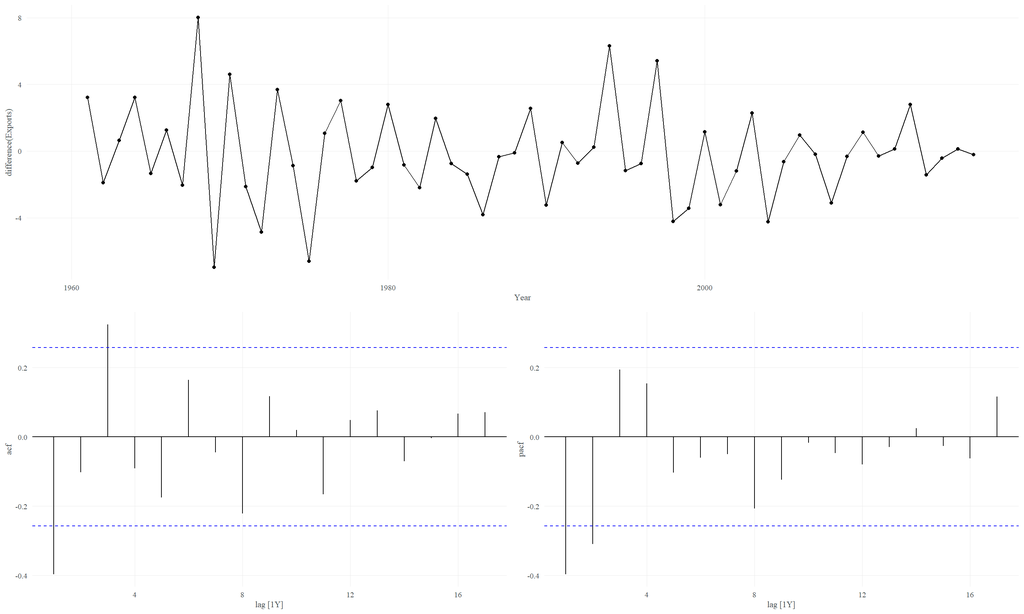

```r
global_economy |>
    filter(Code == "CAF") |>
    gg_tsdisplay(difference(Exports), plot_type = 'partial')
```

### 10.3.1 Fitting

```r
caf_fit <- global_economy |>
    filter(Code == "CAF") |>
    model(arima210 = ARIMA(Exports ~ pdq(2, 1, 0)),
          arima013 = ARIMA(Exports ~ pdq(0, 1, 3)),
          stepwise = ARIMA(Exports),
          search = ARIMA(Exports, stepwise = FALSE))

# show model specifications
caf_fit |> pivot_longer(!Country, names_to = "Model name",
                        values_to = "Orders")
```

```
## # A mable: 4 x 3
## # Key:     Country, Model name [4]
##   Country                  `Model name`         Orders
##   <fct>                    <chr>               <model>
## 1 Central African Republic arima210     <ARIMA(2,1,0)>
## 2 Central African Republic arima013     <ARIMA(0,1,3)>
## 3 Central African Republic stepwise     <ARIMA(2,1,2)>
## 4 Central African Republic search       <ARIMA(3,1,0)>
```

```r
glance(caf_fit) |> arrange(AICc) |> select(.model:BIC)
```

```
## # A tibble: 4 × 6
##   .model   sigma2 log_lik   AIC  AICc   BIC
##   <chr>     <dbl>   <dbl> <dbl> <dbl> <dbl>
## 1 search     6.52   -133.  274.  275.  282.
## 2 arima210   6.71   -134.  275.  275.  281.
## 3 arima013   6.54   -133.  274.  275.  282.
## 4 stepwise   6.42   -132.  274.  275.  284.
```

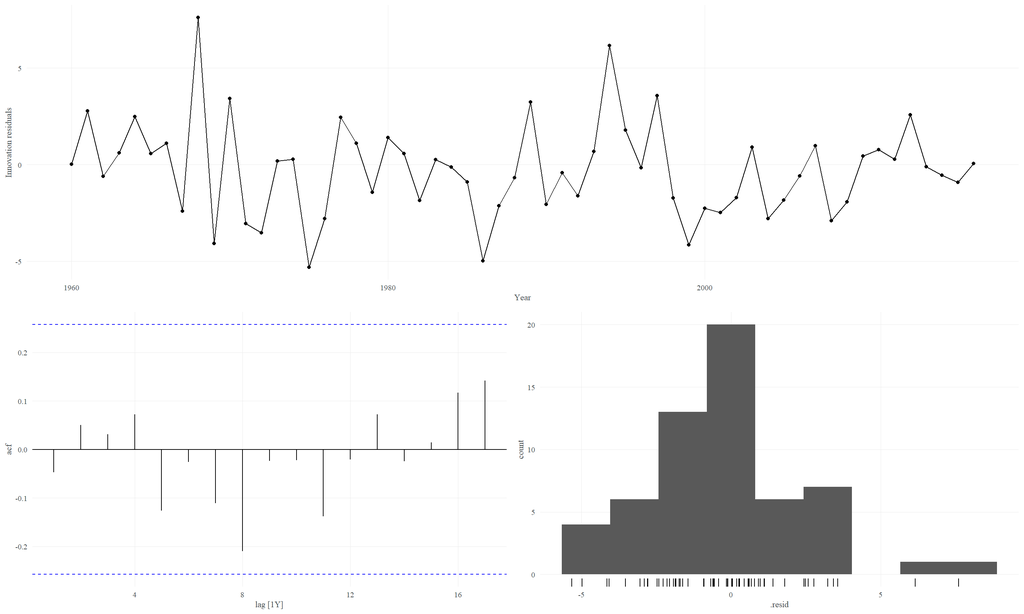

```r
caf_fit |> select(search) |> gg_tsresiduals()
```

### 10.3.2 Portmanteau tests (Ljung-Box tests w/ dof for ARIMA) of residuals for ARIMA models

With ARIMA models, more accurate `portmanteau tests` are obtained if the degrees of freedom of the test statistic are adjusted to take account of the number of parameters in the model. Specifically, we use l-K degrees of freedom in the test, where K is the number of AR and MA parameters in the model. So for the non-seasonal models that we have considered so far, K = p + q. *The value of K is passed to the ljung_box function via the argument dof*, as shown in the example below.

```r
augment(caf_fit) |>
    filter(.model == 'search') |>
    features(.innov, ljung_box, lag = 10, dof = 3)
```

```
## # A tibble: 1 × 4
##   Country                  .model lb_stat lb_pvalue
##   <fct>                    <chr>    <dbl>     <dbl>
## 1 Central African Republic search    5.75     0.569
```

### 10.3.3 Forecast

https://otexts.com/fpp3/a-tidy-forecasting-workflow.html  
- Exports: the forecast distribution  
- .mean: the point forecast

```r
caf_fit |>
    forecast(h = 5) |>
    filter(.model == 'search') |>
    hilo(95)
```

```
## # A tsibble: 5 x 6 [1Y]
## # Key:       Country, .model [1]
##   Country                  .model  Year    Exports .mean                  `95%`
##   <fct>                    <chr>  <dbl>     <dist> <dbl>                 <hilo>
## 1 Central African Republic search  2018 N(13, 6.5)  12.5 [7.499383, 17.50804]95
## 2 Central African Republic search  2019 N(13, 8.5)  12.6 [6.842316, 18.30400]95
## 3 Central African Republic search  2020  N(13, 11)  12.5 [6.103845, 18.89969]95
## 4 Central African Republic search  2021  N(13, 15)  12.5 [4.831547, 20.20349]95
## 5 Central African Republic search  2022  N(13, 18)  12.5 [4.224067, 20.85200]95
```

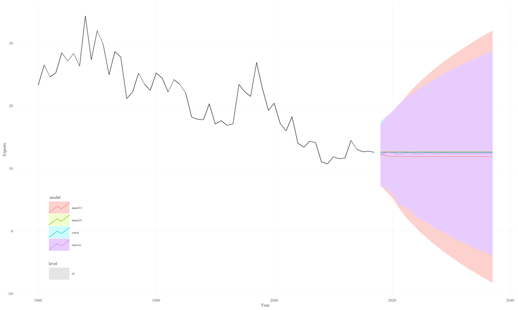

```r
caf_fit |>
    forecast(h = 20) |>
    # filter(.model == 'search') |>
    # filter(.model == 'stepwise') |>
    autoplot(global_economy, 95, fill = col.bmc.pink) +
    theme(legend.position = c(0.1, 0.2))
```

### 10.3.4 Plotting the characteristic roots

`The ARIMA() function will never return a model with inverse roots outside the unit circle.` Models automatically selected by the ARIMA() function will not contain roots close to the unit circle either. Consequently, it is sometimes possible to find a model with better AICc value than ARIMA() will return, but such models will be potentially problematic.

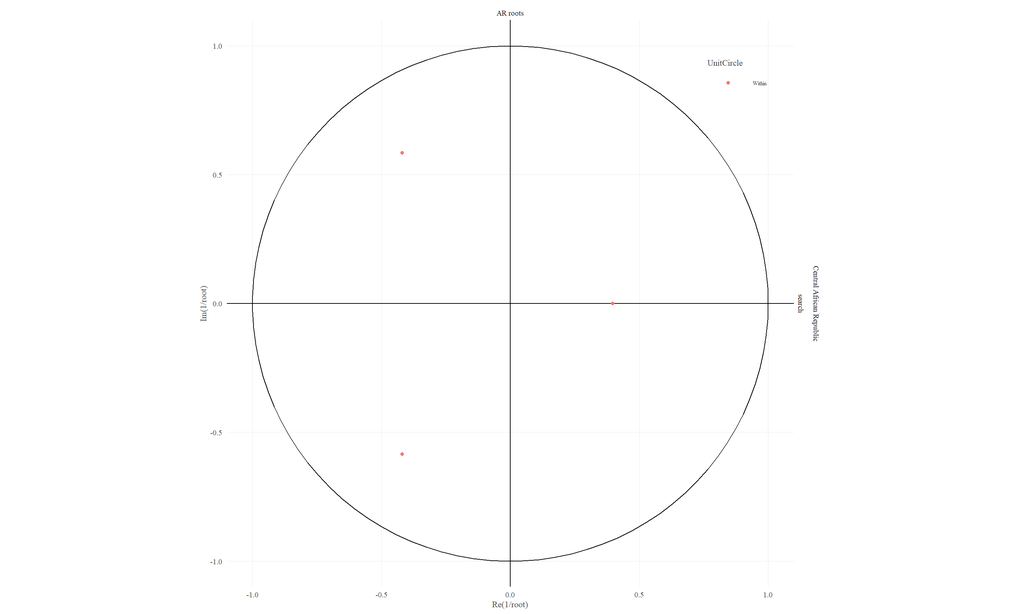

```r
gg_arma(caf_fit |> select(Country, search))
```

# 11 SARIMA: Seasonal ARIMA Modelling

https://otexts.com/fpp3/seasonal-arima.html

## 11.1 Leisure dataset

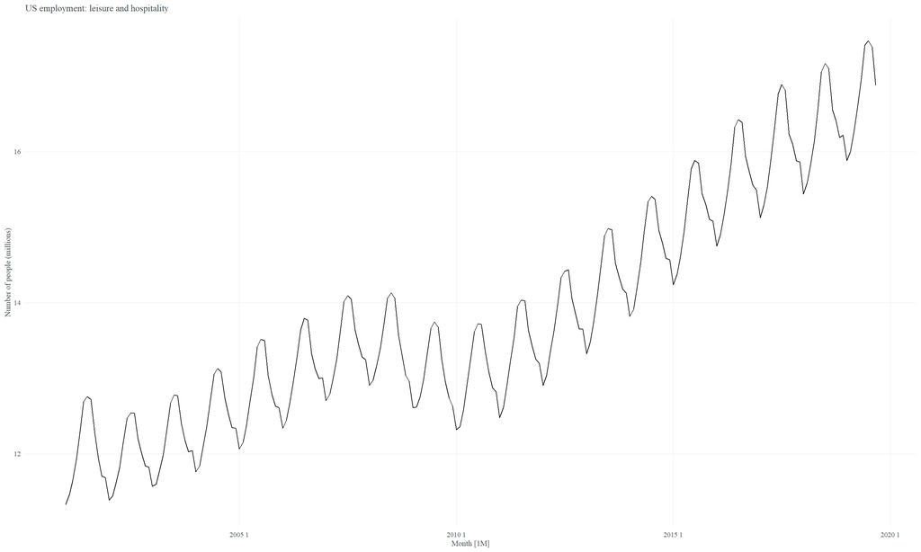

```r
leisure <- us_employment |>
    filter(Title == "Leisure and Hospitality",
           year(Month) > 2000) |>
    mutate(Employed = Employed / 1000) |>
    select(Month, Employed)

autoplot(leisure, Employed) +
    labs(title = "US employment: leisure and hospitality",
         y = "Number of people (millions)")
```

## 11.2 Check ACF and PACF for seasonally differenced time series

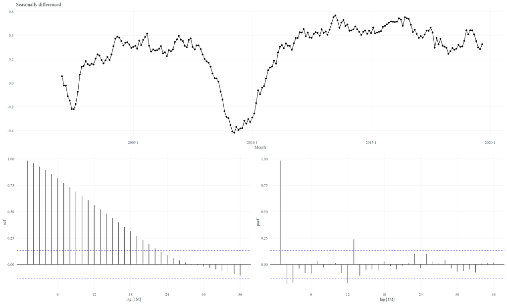

```r
leisure |>
    gg_tsdisplay(difference(Employed, 12),
                 plot_type = 'partial', lag = 36) +
    labs(title = "Seasonally differenced", y = "")
```

## 11.3 Check ACF and PACF for seasonally-further differenced time series

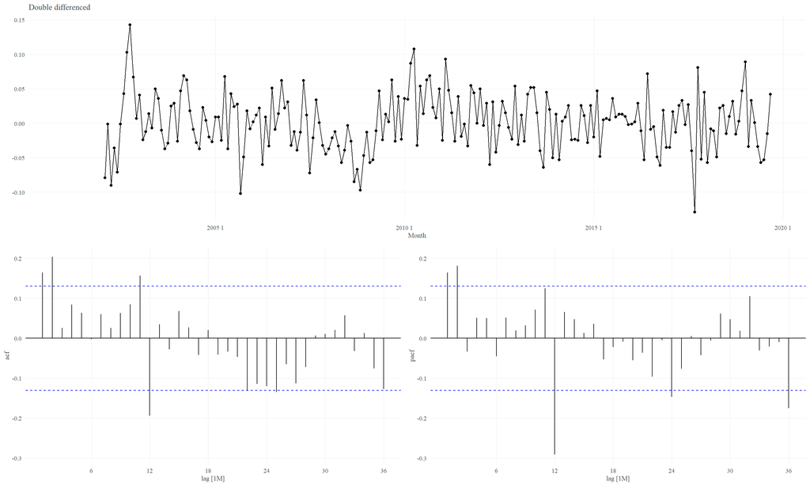

```r
leisure |>
    gg_tsdisplay(difference(Employed, 12) |> difference(),
                 plot_type = 'partial', lag = 36) +
    labs(title = "Double differenced", y = "")
```

## 11.4 Ljung-Box Statistics and KPSS

```r
leisure %>%
    mutate(diff_Employed = difference(Employed, 12) %>% difference()) %>%
    features(diff_Employed, ljung_box, lag = 10)
```

```
## # A tibble: 1 × 2
##   lb_stat lb_pvalue
##     <dbl>     <dbl>
## 1    20.8    0.0227
```

```r
leisure %>%
    mutate(diff_Employed = difference(Employed, 12) %>% difference()) %>%
    features(diff_Employed, unitroot_kpss)
```

```
## # A tibble: 1 × 2
##   kpss_stat kpss_pvalue
##       <dbl>       <dbl>
## 1    0.0849         0.1
```

## 11.5 Fitting

```r
fit <- leisure |>
    model(
        arima012011 = ARIMA(Employed ~ pdq(0, 1, 2) + PDQ(0, 1, 1)),
        arima210011 = ARIMA(Employed ~ pdq(2, 1, 0) + PDQ(0, 1, 1)),
        auto = ARIMA(Employed, stepwise = FALSE, approx = FALSE)
    )

fit |> pivot_longer(everything(), names_to = "Model name",
                    values_to = "Orders")
```

```
## # A mable: 3 x 2
## # Key:     Model name [3]
##   `Model name`                    Orders
##   <chr>                          <model>
## 1 arima012011  <ARIMA(0,1,2)(0,1,1)[12]>
## 2 arima210011  <ARIMA(2,1,0)(0,1,1)[12]>
## 3 auto         <ARIMA(2,1,0)(1,1,1)[12]>
```

```r
glance(fit) |> arrange(AICc) |> select(.model:BIC)
```

```
## # A tibble: 3 × 6
##   .model       sigma2 log_lik   AIC  AICc   BIC
##   <chr>         <dbl>   <dbl> <dbl> <dbl> <dbl>
## 1 auto        0.00142    395. -780. -780. -763.
## 2 arima210011 0.00145    392. -776. -776. -763.
## 3 arima012011 0.00146    391. -775. -775. -761.
```

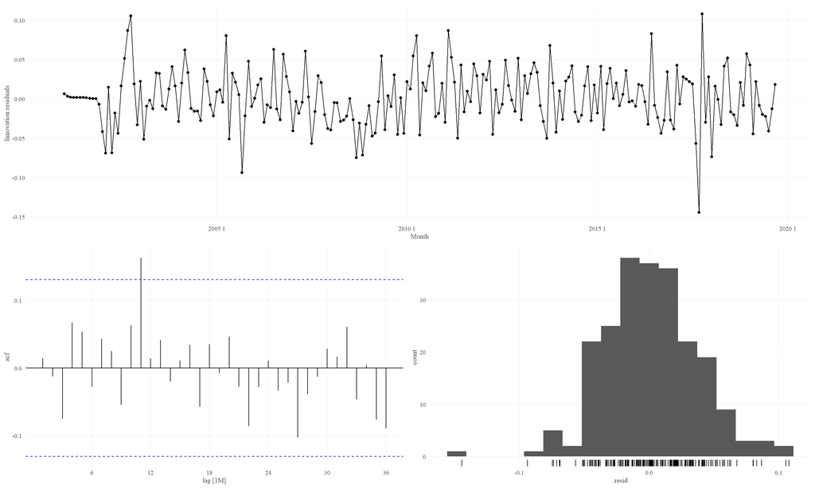

```r
fit |> select(auto) |> gg_tsresiduals(lag = 36)
```

## 11.6 Ljung-Box test on residuals

```r
augment(fit) |>
    filter(.model == "auto") |>
    features(.innov, ljung_box, lag = 24, dof = 4)
```

```
## # A tibble: 1 × 3
##   .model lb_stat lb_pvalue
##   <chr>    <dbl>     <dbl>
## 1 auto      16.6     0.680
```

## 11.7 Forecast

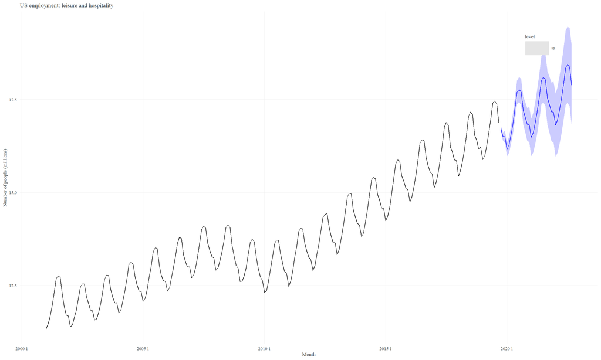

```r
forecast(fit, h = 36) |>
    filter(.model == 'auto') |>
    autoplot(leisure, 95) +
    labs(title = "US employment: leisure and hospitality",
         y = "Number of people (millions)")
```

# 12 References

- https://otexts.com/fpp3/stationarity.html